# Data Science Capstone Project - Word Prediction

March 18, 2017

## Overview

This presentation is a part of deliverable required for Data Science Capstone project.

The objective of this project is to build a working predictive text model. The data used in the model came from a **corpus** called HC Corpora (www.corpora.heliohost.org). A corpus is body of text, usually containing a large number of sentences.

This corpus was used to calculate different N-gram units that will be used later by prediction algorithm.

## Prediction Engine Building

The algorithm developed to predict the next word(s) in a user-entered text string was based on a classic **N-gram** model. Using a subset of cleansed data from blogs, twitter, and news Internet files, **Maximum Likelihood Estimation** (MLE) of unigrams, bigrams, and trigrams were computed.

To improve accuracy, **Jelinek-Mercer smoothing** was used in the algorithm, combining trigram, bigram, and unigram probabilities. Whenever interpolation failed, **part-of-speech tagging** (POST) was employed to provide default predictions by part of speech.

## Web Application

A shiny web application was built based on above algorithm logic and flow.

The application is developed to accept user input and instantly calculates next 4 words. Those words are selected based on best match possible.

The application demo built by Shiny and can be found at the URL: https://mam-moneim.shinyapps.io/datasciencecapstone/

Source code is at GitHub for the application and presentation at the URL: https://github.com/mmonim/Coursera-DataScience-Capstone-Project

## Sample Layout of the application

Herein below a screen shot of the application along its various sections. User can start typing his own phrase and system will instantly and continuosly run prediciton algorithm to come up with next 4 best-fit words.

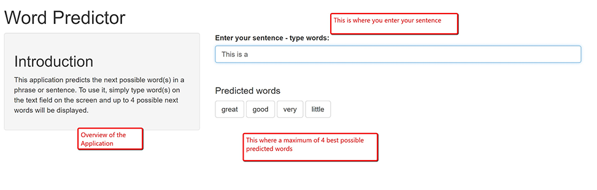

Application screen shot